# Analysis ESF-Survey

## Summary and General Info

### Progress throughout Survey

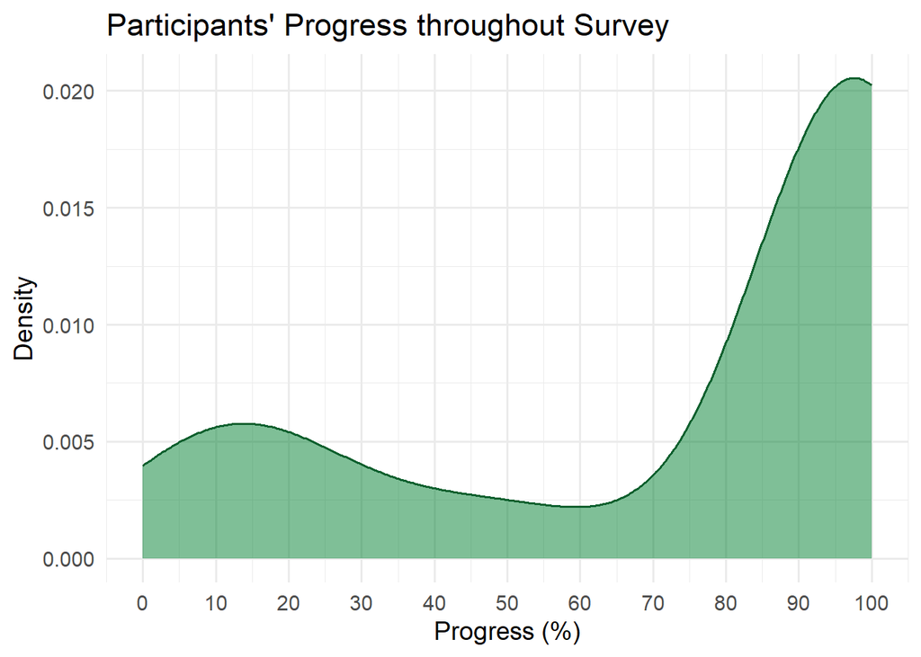

- mean participant progression: 75.341%
- two small peaks: some participants started but did not make it past the first two open-ended questions (number of participants stopping at or before 30%: $n = 17$), and many participants made it to the last page (participants reaching at least 90%: $n =57$)

### Scrolling Behavior

- counterintuitively to our expectation, not many participants actually used TikTok: $n_\text{TikTok} = 21$ ($25.6\%$)
- the majority of participants used Instagram: $n_\text{Instagram} = 44$ ($53.7\%$)
- and a minority used a platform other than instagram or TikTok: $n_\text{other} = 11$ ($13.4\%$)

## Open Associations

### When you browsed through your social media feed, which content-related thoughts crossed your mind?

$n = 68$ answered this question.

#### Summary

When we just ask about *content-related thoughts*, there is little to no associations with origin, origin ambiguity or AI in particular.

|  | Considerations | TikTok | Instagram | Other |
| --- | --- | --- | --- | --- |
| 1 | cool, follower count of account i visited, some disturbing content concerning war | 0 | 1 | 0 |
| 2 | -I watched a make-up video, which I saved to reproduce it for my dinner tonight | 0 | 1 | 0 |
| 3 | Success, edits, humorous edits, funny memes, making fun of people, music | 0 | 1 | 0 |
| 4 | Funny Videos Inspiring Videos Some weird videos | 1 | 0 | 0 |
| 5 | nothing | 0 | 0 | 1 |
| 6 | I was less engaged because the consumption felt forced through the lecture. I had different thoughts/associations (posts about girlfriend, funny videos) | 0 | 1 | 0 |
| 7 | I need to plan my holidays | 1 | 0 | 0 |
| 8 | Thoughts related to the posts or reels, laughing or seein something nice and thinking it and then going to search it or something similar. | 0 | 1 | 0 |
| 9 | University lifestyle, relatable situations in real life | 0 | 1 | 0 |
| 10 | University courses, ordinary life tasks, pets, skiing, boyfriend, friends, christmas events | 0 | 1 | 0 |

[output cut: 58 more lines]

### Social media content can be created in different ways. When browsing your social media feed, did you wonder how some of the content was created?

$n = 68$ answered this question.

#### Summary

When asking specifically about *creation of content*, we do get some associations with AI:

- “AI generated Memes, Edits, Animated videos, Picture-Slideshows”
- “at some point yes, because some videos are most likely created with artificial intelligence. But nowadays sometimes you can‘t tell if the content is real or made up.”
- ” Sometimes there are AI created content, thats more interesting but this time that wasn‘t the case”
- and others

|  | Evaluations | TikTok | Instagram | Other |
| --- | --- | --- | --- | --- |
| 1 | Yes, some content looked really greatly edited so I was thinking that this must have taken quite some time | 0 | 1 | 0 |
| 2 | no | 0 | 1 | 0 |
| 3 | yes, especially the edits, which are of great quality sometimes, i wonder where they get their material from and how they cut it, and who takes the time to create all that content. | 0 | 1 | 0 |
| 4 | No, i didn‘t think at all how it was created. | 1 | 0 | 0 |
| 5 | idk | 0 | 0 | 1 |
| 6 | not realy | 0 | 1 | 0 |
| 7 | I sometimes think of what tools they have used to edit their stuff | 1 | 0 | 0 |
| 8 | Usually I think about it because I can understand how it was made and it's something well made, nicely shot I'll think it's nice and share it. | 0 | 1 | 0 |
| 9 | AI generated Memes, Edits, Animated videos, Picture-Slideshows | 0 | 1 | 0 |
| 10 | No, not really, but at some point yes, because some videos are most likely created with artificial intelligence. But nowadays sometimes you can‘t tell if the content is real or made up. | 0 | 1 | 0 |

[output cut: 58 more lines]

### How much of the content you consumed in the last few minutes do you remember?

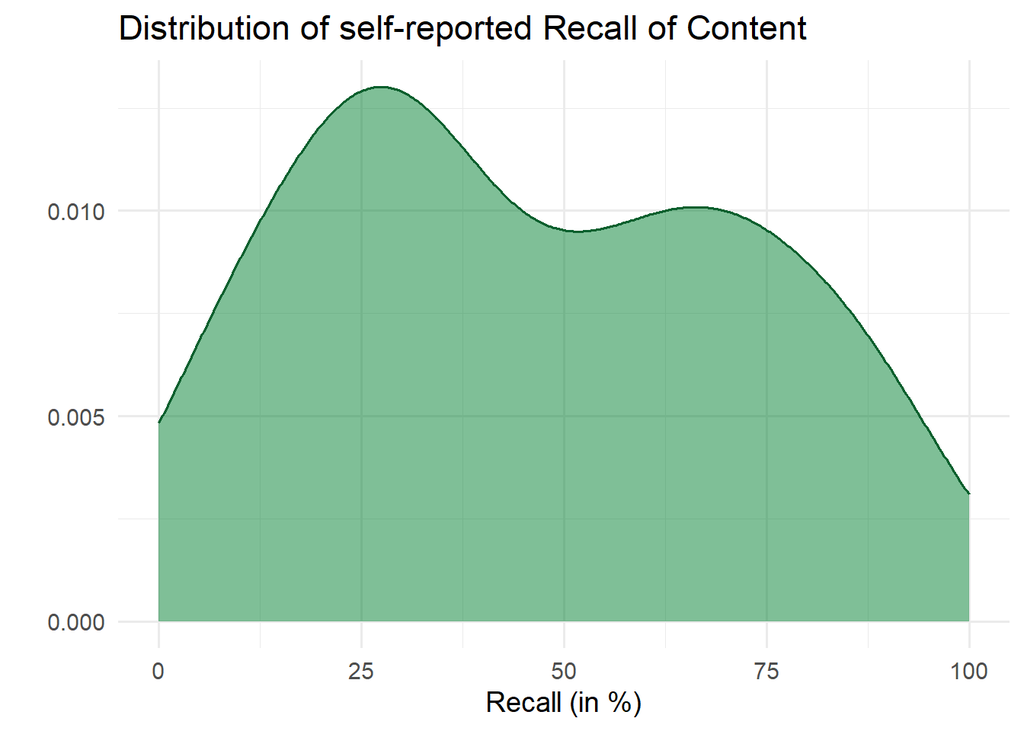

In general, participants reported to not recall much of the content they had just consumed (just under 50%: $mean_\text{Recall} = 45.877$, ($SD_\text{Recall} =27.112$).

Recall did not significantly differ between platforms (TikTok, Instagram, Other).

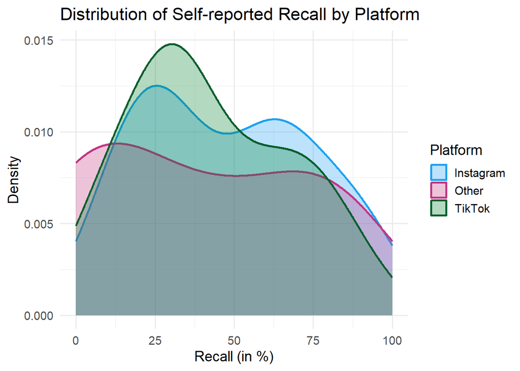

```
    Kruskal-Wallis rank sum test

data:  recall_selfreport_1 by platform
Kruskal-Wallis chi-squared = 0.81301, df = 2, p-value = 0.666
```

### Origin Ambiguity

We asked a total of 6 questions pertaining to origin ambiguity:

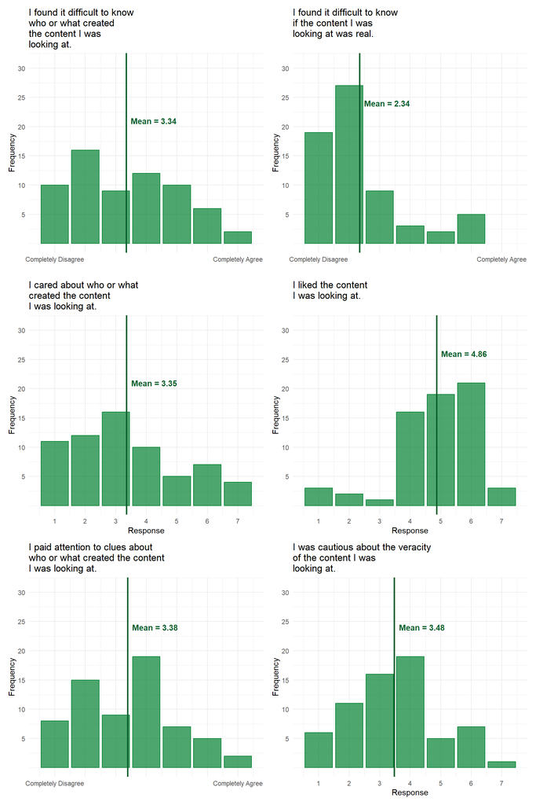

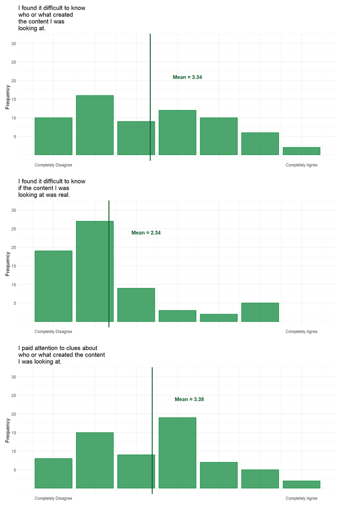

Most responses were neither skewed in one or the other direction, implying moderate agreement. Surprisingly, our results show a tendency to rather not have experienced origin ambiguity in the past couple of minutes, as indicated by a mean of $mean_\text{real} = 2.338$ ($SD_\text{real} =1.428$).

## General Perception

The subsequent questions were asked about participants’ **social media feed overall**, not the past two minutes.

### Thinking about your social media feed overall, what proportion of the content you see is …

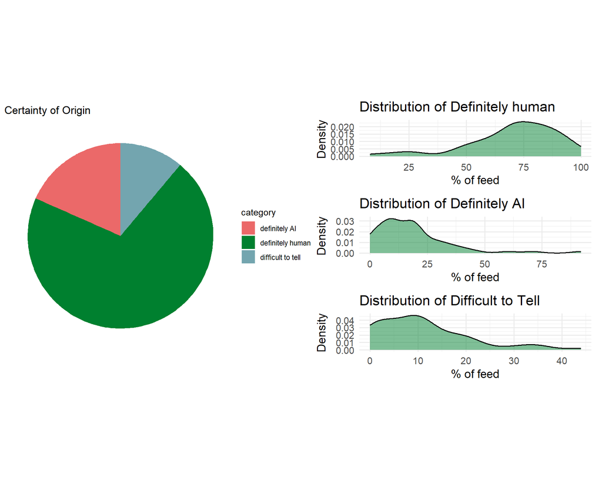

#### Instagram Only

[figure not shown]

#### TikTok Only

[figure not shown]

It appears that people think a majority of the content they consume has been created by a human. However, when asked about the involvement of AI, much of the content is perceived as at least augmented by AI. This dichotomy could be resolved in several ways. One possiblity is that participants misunderstood the first question and interpreted “definitely made by AI” as meaning 100% bot accounts without any human involvement. The second possibility is that participants perceive content based on a human-written prompt or base image (augmentation) as still clearly made by a human, although the human had help from AI.

### When I am not sure about the origin of the content, I …

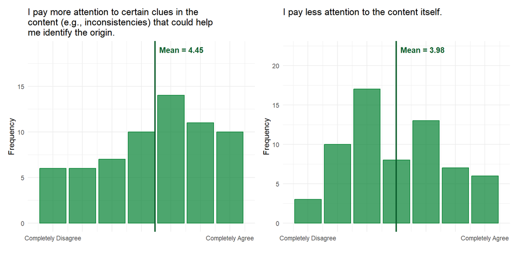

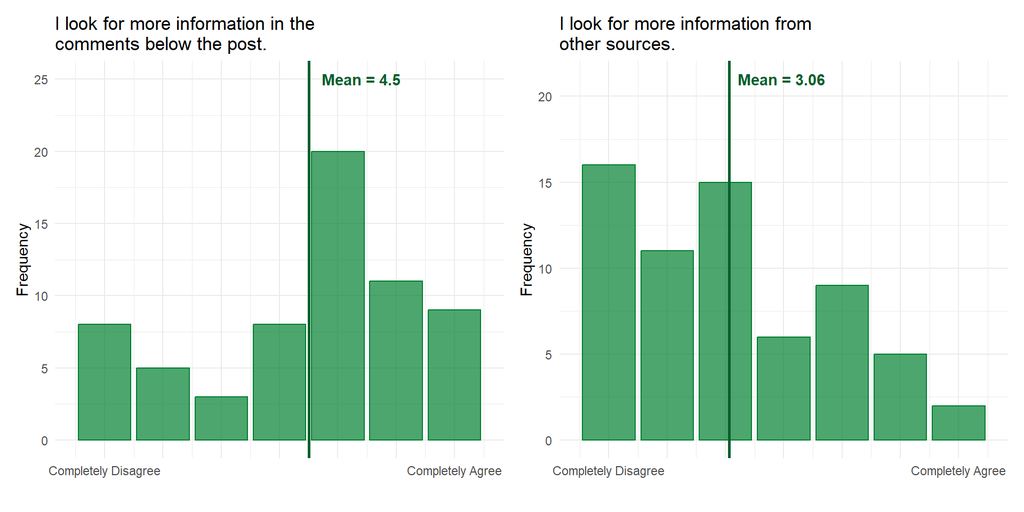

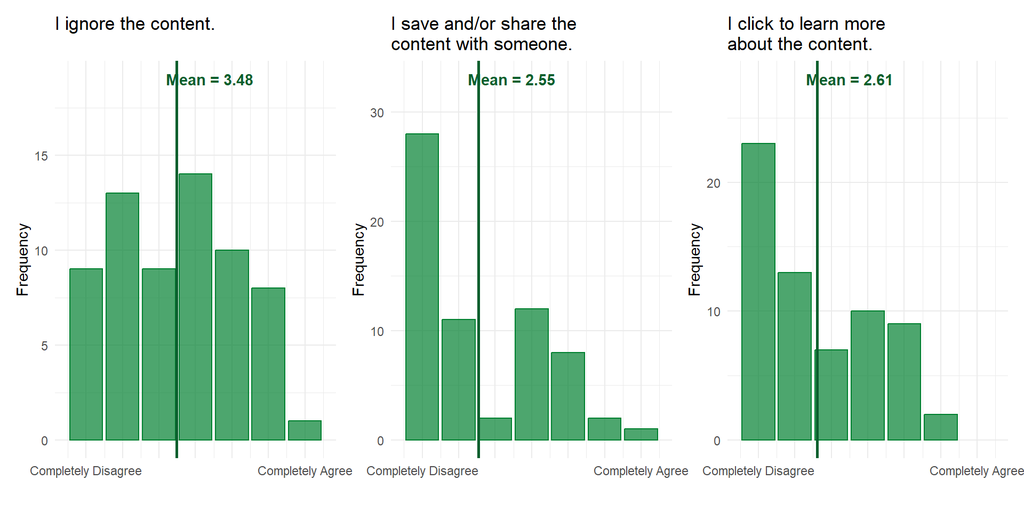

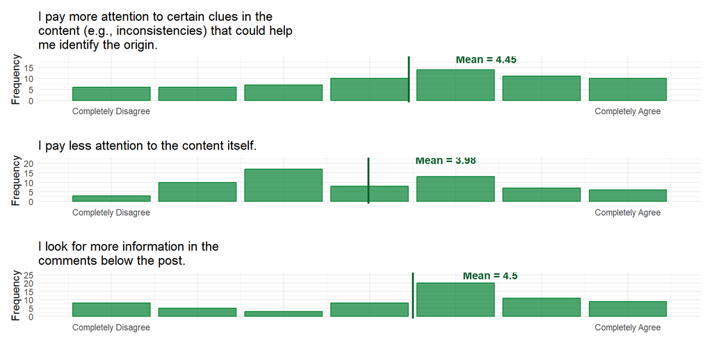

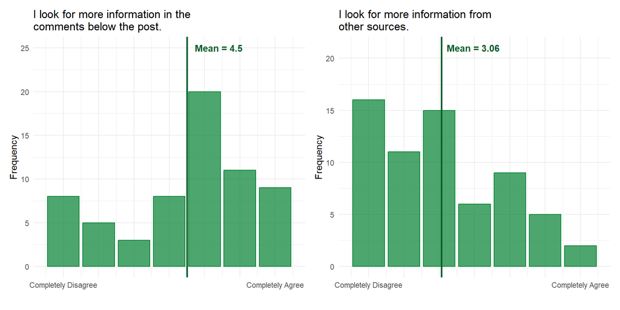

While people generally seem to experience origin ambiguity infrequently (as indicated by the questions above), *when* they experience it, their behavior follows some of the core patterns we hypothesized: People pay more attention to context clues, slightly less attention to the content itself, and go to the comments to inform themselves.

## Specific Questions

The following questions were asked about participants’ perception of their social media feed they scrolled through **just now**.

### Thinking about your social media feed you scrolled through in the last few minutes, what proportion of the content you saw was …

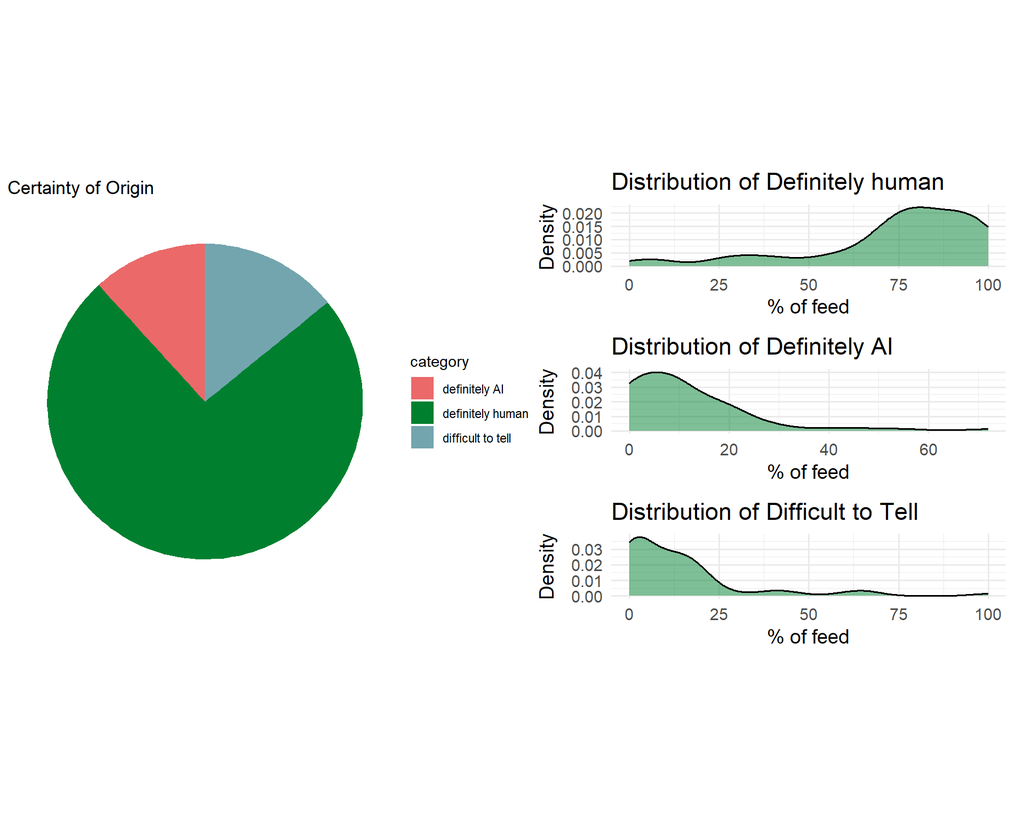

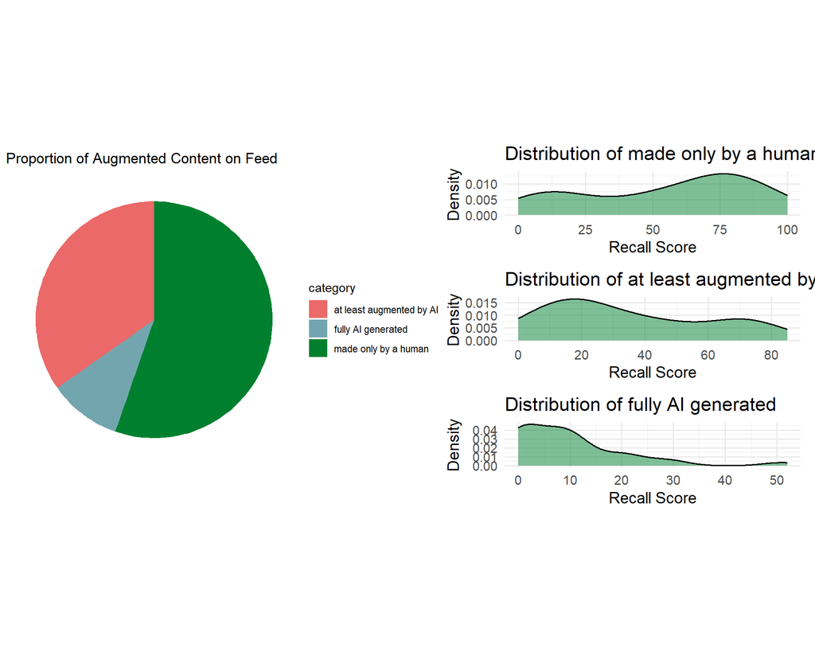

When asking participants about the content they just watched, the patterns regarding origin assumptions and augmentation remain the same.

### Specific Instances

Of all respondents, $n = 15$ reported that they recalled a specific instance of content they wondered was generated by AI. $n =48$ did report that there was no content generated by AI. In total, $n = 22$ instances were reported, meaning that some participants recalled more than one instance. The following charts summarize responses across all instances, meaning that certain participants repeat.

### Description of the Instance(s)

|  | instances |
| --- | --- |
| 1 | Visuals |
| 2 | Reality |
| 3 | Content |
| 4 | I saw a POV-video of a goat climbing mountains and it looked too good to be true |
| 5 | no real visuals |
| 6 | KI sign of instagram |
| 7 | There was an accident with a truck and it seemed like it was AI but at the same time it looked real. |
| 8 | Political Content |
| 9 | Reels/Shorts in general |
| 10 | Overall Content |

[output cut: 12 more lines]

### Reasons Given

|  | reason |
| --- | --- |
| 1 | If it suits the reality or not |
| 2 | I have never seen something like this before and at the same time it looked better than real life |
| 3 | not real proportions of objects |
| 4 | The truck seemed AI generated |
| 5 | The quality in non-information-carrying contents; in information-carrying contents probably the information itself, that I already consumed in more serious sources before |
| 6 | The background did't look realistic |
| 7 | It would just be very easy to do those things with AI and some of the text just doesn‘t necessarily seem written by a human. |
| 8 | Because it was not edited in a difficult way but at the same time showed real clips. Which makes me qestion, whether a human actually put in the work or outsourced it to AI. |
| 9 | no |
| 10 | it looked unreal. |

[output cut: 9 more lines]

### Modality and Type

Looking at the modality of content, the overwhelming majority of examples given seems to be videos. Almost all examples stem from the entertainment domain.

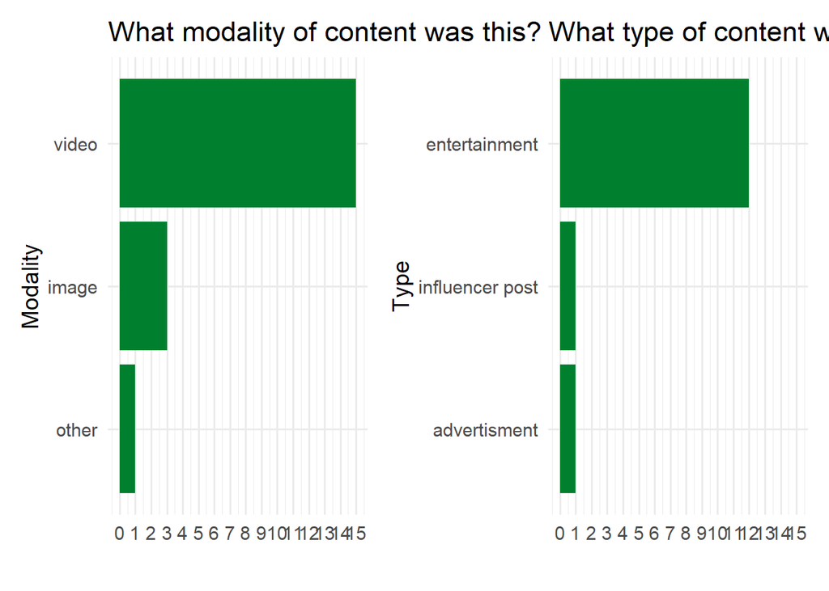

### Certainty and Involvement

On average, participants were $mean_\text{certainty} = 61.474, SD_\text{certainty} =24.939$ certain that the content they were referring to was AI-generated. Additionally, participants tended to say AI was rather more involved than less ($mean_\text{involvement} = 68.053, SD_\text{certainty} =31.722$). The correlation between certainty and involvement is $r = 0.579964$. However, as visualized in the plot, the number of data points is low and the dispersion is large.

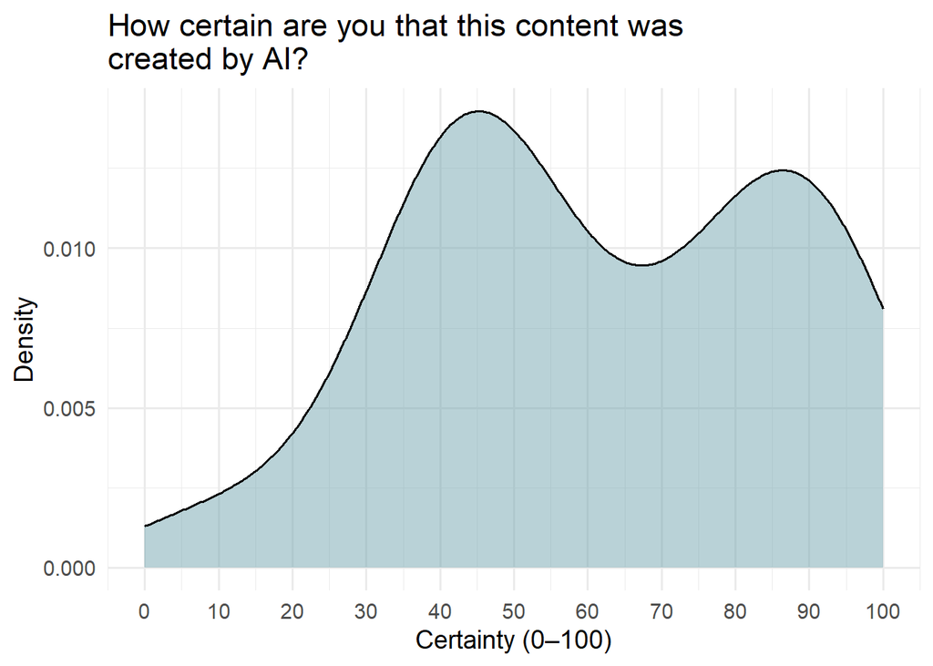

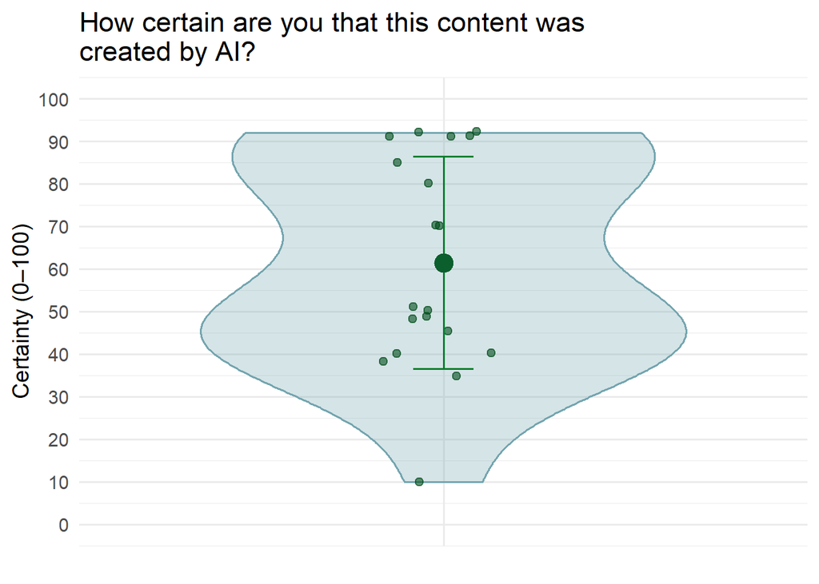

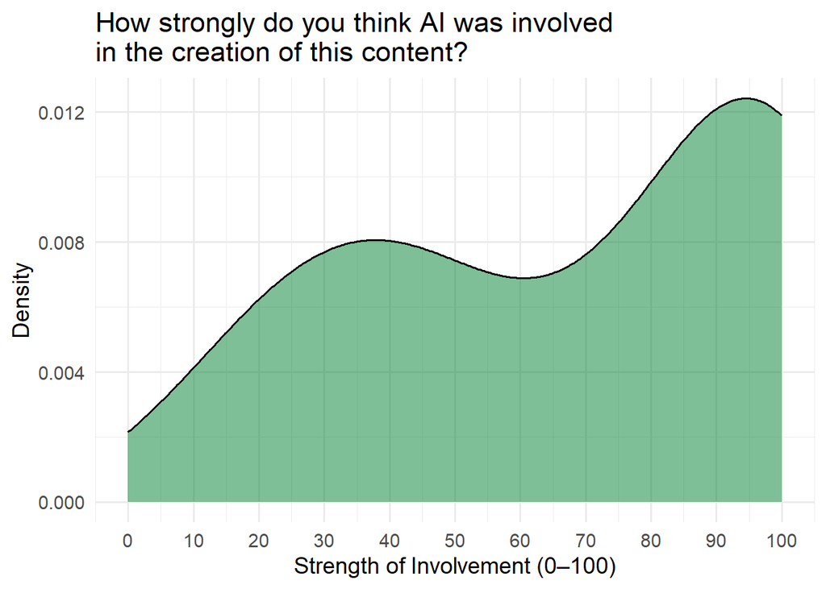

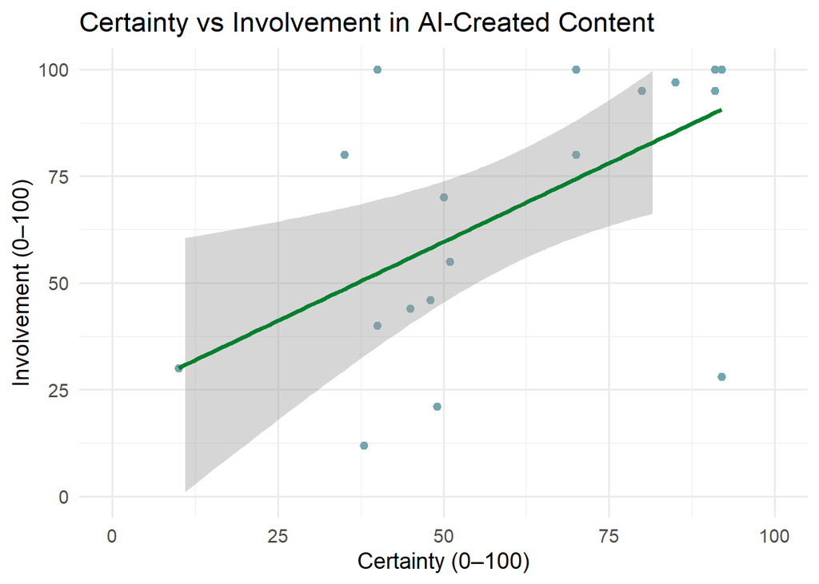

### Reactions

After seeing the content, I …

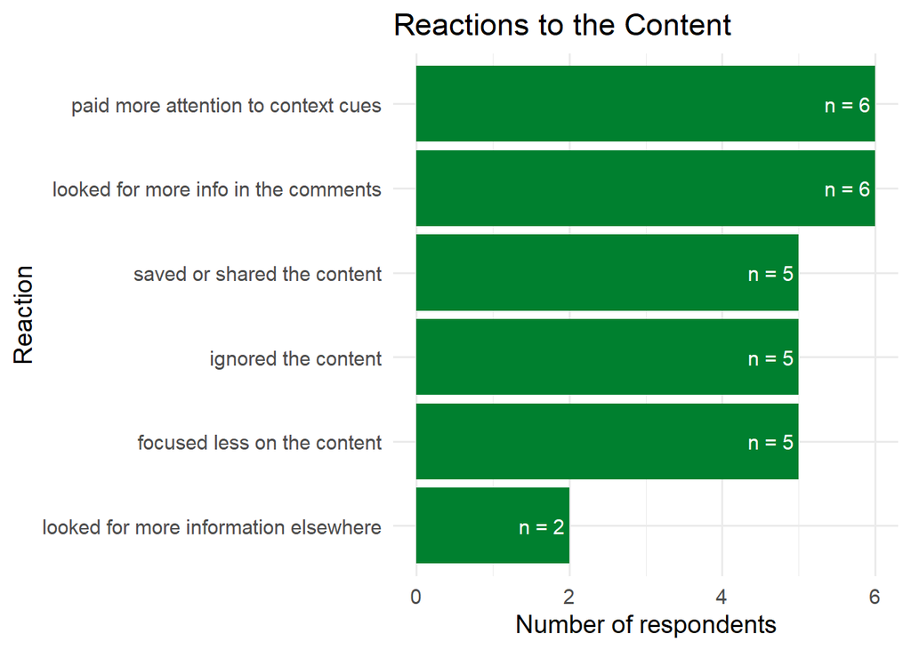

Reactions to the content again demonstrate that at least some effects we hypothesize seem to occurr: Paying attention to context cues, and looking for additional information.

## Demographics & Controls

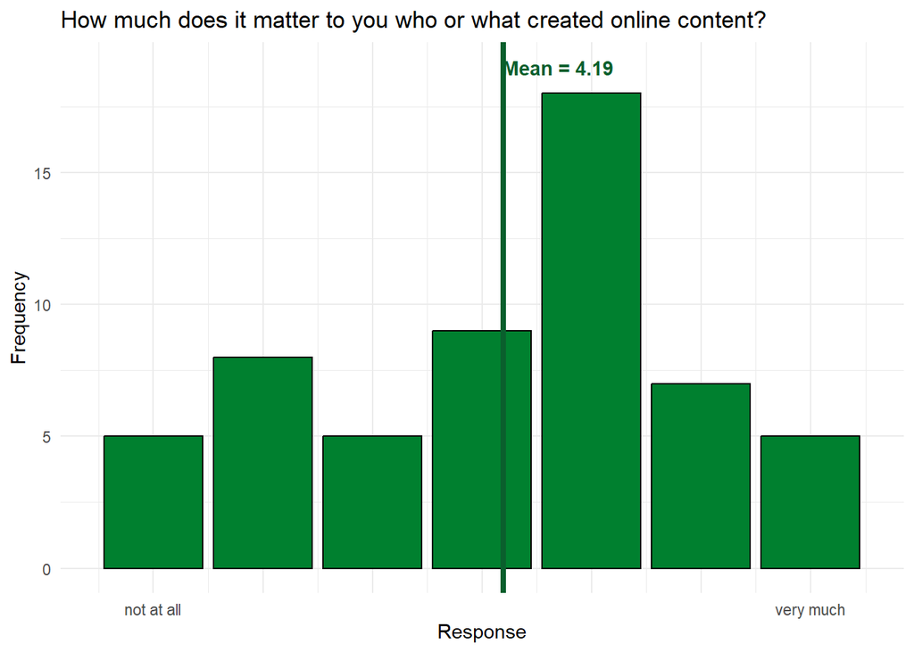

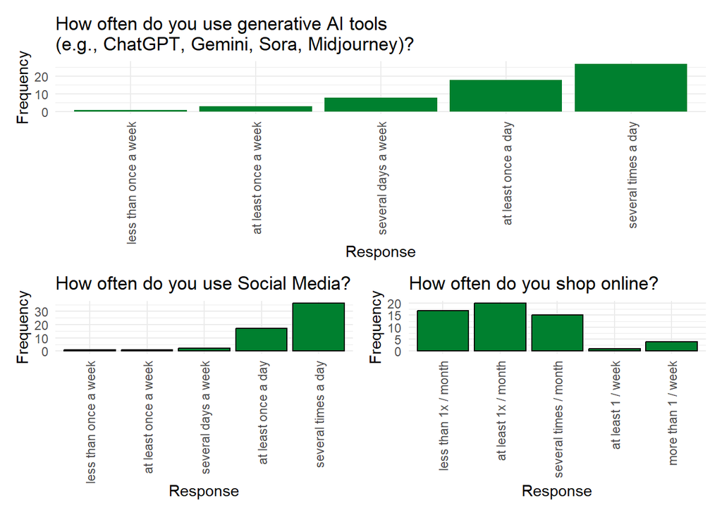

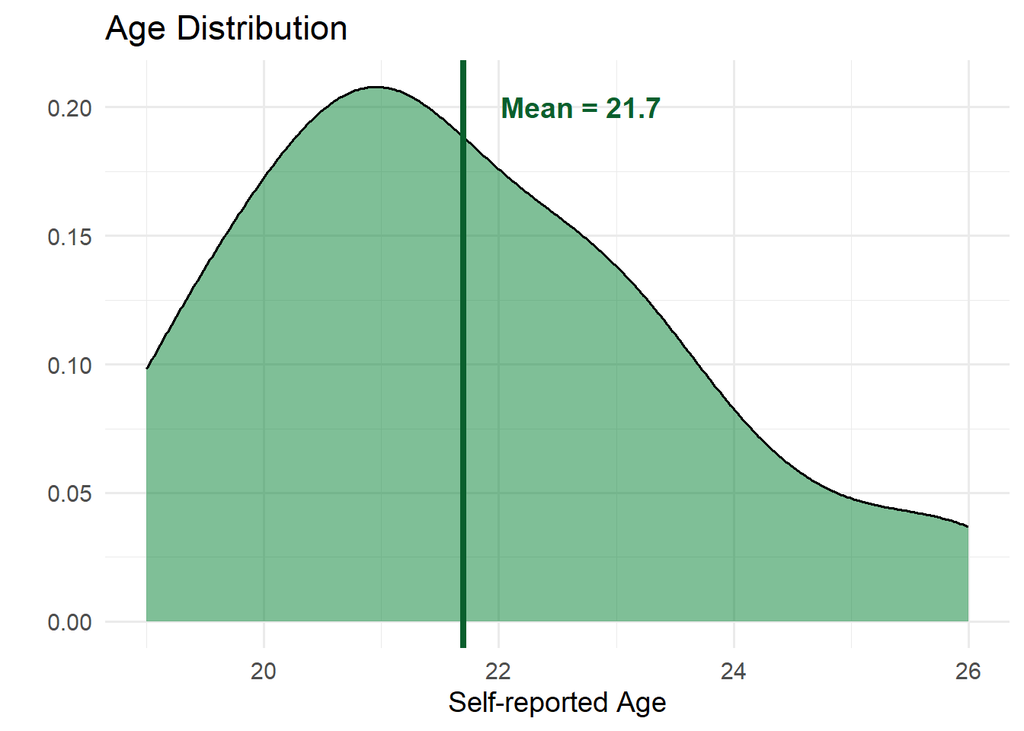

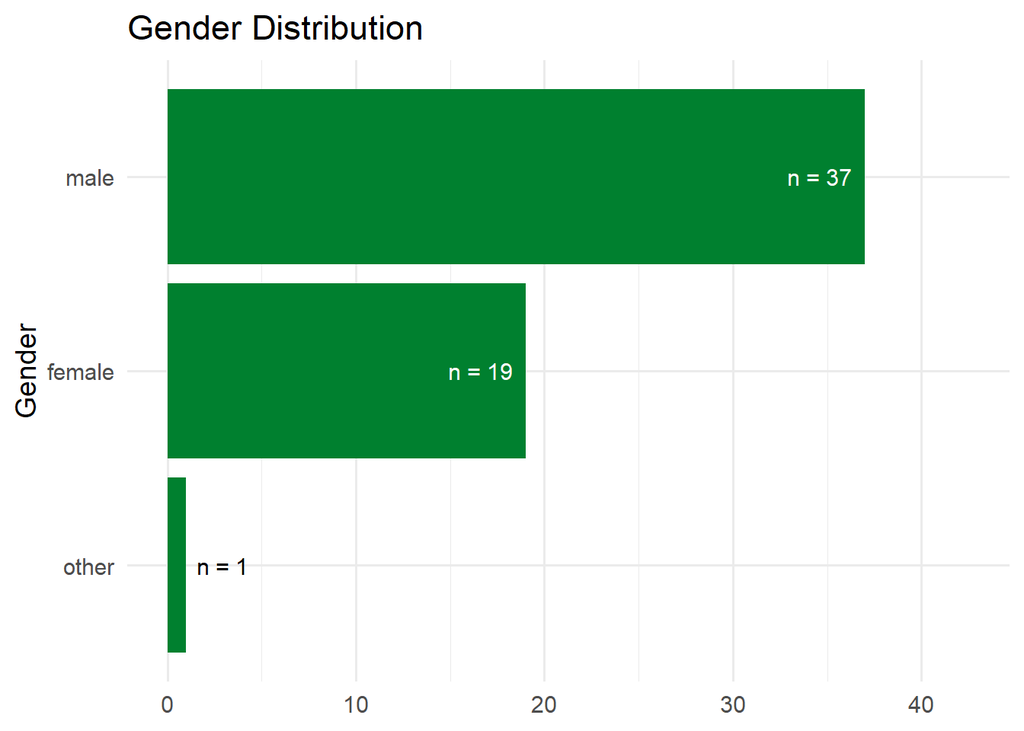

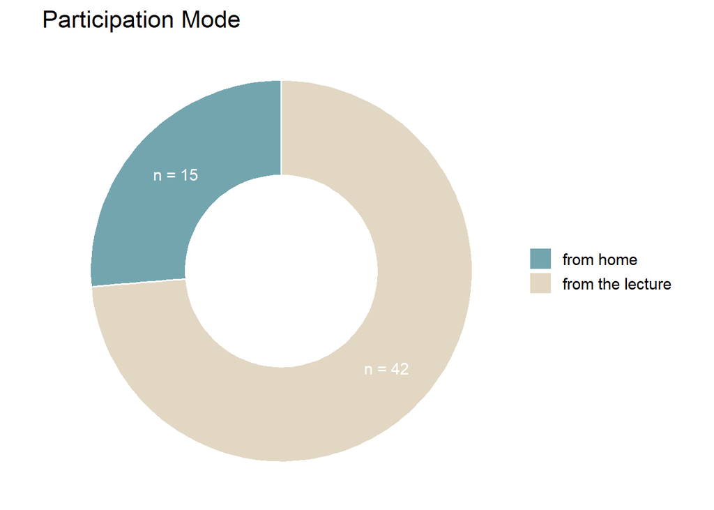

# Correlations and Relations

## General Origin Ambiguity Perception

### Correlations within Closed Associations about Origin Ambiguity

```
                               difficulty knowing
difficulty knowing                     1.00000000
difficulty knowing what's real         0.33034226
cared about origin                    -0.19839338
liked content                          0.13525129
paid attention to clues               -0.30811177
cautious about veracity                0.02184445
                               difficulty knowing what's real
difficulty knowing                                 0.33034226
difficulty knowing what's real                     1.00000000
cared about origin                                -0.12097693
liked content                                      0.02456798
paid attention to clues                            0.05193460
cautious about veracity                            0.07077862
                               cared about origin liked content
difficulty knowing                    -0.19839338    0.13525129
difficulty knowing what's real        -0.12097693    0.02456798
cared about origin                     1.00000000    0.09132713
liked content                          0.09132713    1.00000000
paid attention to clues                0.49031909    0.09765086
cautious about veracity                0.28543757    0.18257730
                               paid attention to clues cautious about veracity
difficulty knowing                         -0.30811177              0.02184445
difficulty knowing what's real              0.05193460              0.07077862
cared about origin                          0.49031909              0.28543757
liked content                               0.09765086              0.18257730
paid attention to clues                     1.00000000              0.44912153
cautious about veracity                     0.44912153              1.00000000
```

**Summary**

- People who found themselves looking for clues about the origin of something also found themselves to wonder about the veracity of content ($r = 0.4491215$)
- people who **cared** about who or what created the content also paid attention to context cues ($r = 0.4903191$) and cared about the veracity of the content ($r = 0.2854376$)

### Correlation between perceived Ambiguity in the last 2 minutes and Recall of Content

The self-reported recall of content in percent did not correlate strongly with the perceived content having been created by AI ($r = 0.1156987$), by a human ($r = -0.1056542$) or ambiguous ($r = -0.0726594$).

### Correlation within General Statements about Reactions to Origin Ambiguity

```
                              clues less attention to content
clues                     1.0000000                0.21904884
less attention to content 0.2190488                1.00000000
more info comments        0.4168168                0.29715661
more info elsewhere       0.3739845                0.19902439
ignore                    0.1522764                0.50983421
save or share             0.2614795               -0.01883165
learn more                0.2903580                0.02730336
                          more info comments more info elsewhere      ignore
clues                              0.4168168           0.3739845  0.15227640
less attention to content          0.2971566           0.1990244  0.50983421
more info comments                 1.0000000           0.3408109  0.19894638
more info elsewhere                0.3408109           1.0000000  0.21696023
ignore                             0.1989464           0.2169602  1.00000000
save or share                      0.4070484           0.1667480 -0.13723707
learn more                         0.2568025           0.4871292  0.05441681
                          save or share learn more
clues                        0.26147955 0.29035801
less attention to content   -0.01883165 0.02730336
more info comments           0.40704838 0.25680254
more info elsewhere          0.16674795 0.48712924
ignore                      -0.13723707 0.05441681
save or share                1.00000000 0.31032154
learn more                   0.31032154 1.00000000
```

**Summary**